# Cluster Analysis and Segmentation: Boat Case

**Ignacio Fantaguzzi, Kenta Sakakibara, Linna Bun, Rudy Yazbek**

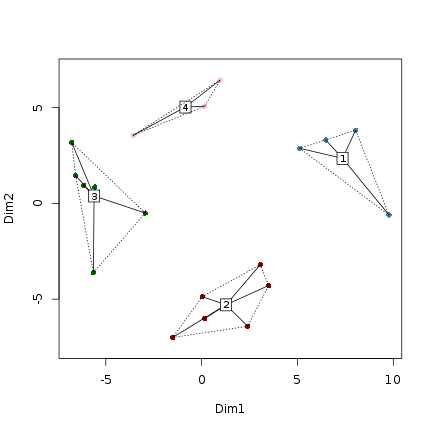

1. Confirm the data in metric
2. Decide whether to scale or standardize the data
3. Decide which variables to use for clustering
4. Define similarity or dissimilarity measures between observations
5. Visualize Individual Attributes and Pair-wise Distances between the Observations
6. Select the clustering method to use and decide how many clusters to have
7. Profile and interpret the clusters
8. Assess the robustness of our clusters

#### Step 1. Confirm the data in metric

> In general, a “best practice” for segmentation is to creatively define distance metrics between our observations.

#### Step 3. Decide which variables to use for clustering

In our case, we can use the 5 attitudinal questions for segmentation, and the remaining for profiling later.

#### Step 4. Define similarity or dissimilarity measures between observations

In our case we explore two distance metrics: the commonly used **Euclidean distance** as well as a simple one we define manually.

#### Step 5. Visualize Individual Attributes and Pair-wise Distances between the Observations

or the histogram of all pairwise distances for the euclidean distance:

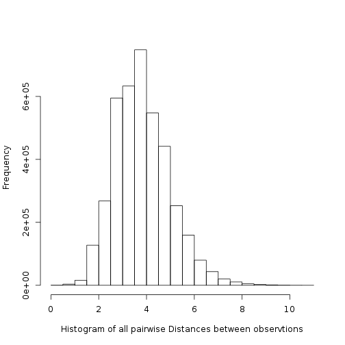

#### Step 6. Select the clustering method to use and decide how many clusters to have

Let's fist use the **Hierarchial Clustering** method, as we do not know for now how many segments there are in our data. Hierarchical clustering is a method that also helps us visualise how the data may be clustering together. It generates a plot called the **Dendrogram** which is often helpful for visualization - but should be used with care. For example, in this case the dendrogram, using the euclidean distance metric from the earlier steps and the ward hierarchical clustering option (see below as well as help(hclust) in R for more information), is as follows:

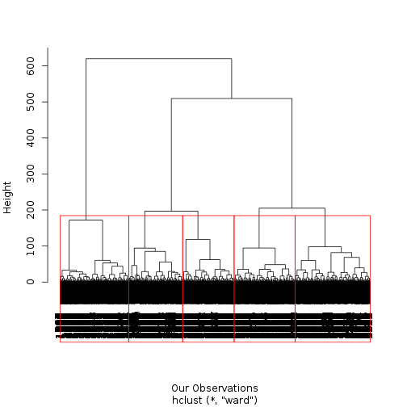

Note that we can draw as many clusters are we choose (e.g. in this case we chose 5 clusters) around the branches of the Dendrogram.

As a rule of thumb, one can select the number of clusters as the “elbow” of this plot: this is the place in the tree where, if we traverse the tree from the leaves to its root, we need to make the “longest jump” before we merge further the segments at that tree level. Of course the actual number of segments can be very different from what this rule of thumb may indicate: in practice we explore different numbers of segments, possibly starting with what a hierarchical clustering dendrogram may indicate, and eventually we select the final segmentation solution using both statistical and qualitative criteria, as discussed below.

**Using Kmean Clustering**

As always, much like Hierarchical Clustering can be performed using various distance metrics, so can Kmeans. Moreover, there are variations of Kmeans (e.g. “Hartigan-Wong”, “Lloyd”, or “MacQueen” - see help(kmeans) in R) one can explore, which are beyond the scope of this note.

Note that the observations do not need to be in the same clusters as we use different methods, neither do the segment profiles that we will find next. However, a characteristic of **statistically robust segmentation** is that our observations are grouped in similar segments independent of the approach we use. Moreover, the profiles of the segments should not vary much when we use different approaches or variations of the data. We will examine this issue in the last step, after we first discuss how to profile segments.

#### Step 7. Profile and interpret the clusters

Having decided (for now) how many clusters to use, we would like to get a better understanding of who the customers in those clusters are and interpret the segments.

We can also “visualize” the segments using **snake plots** for each cluster. For example, we can plot the means of the profiling variables for each of our clusters to better visualize differences between segments. For better visualization we plot the standardized profiling variables.

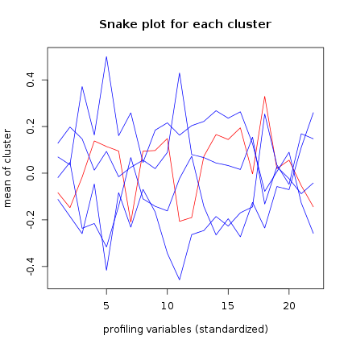

We can also compare the averages of the profiling variables of each segment relative to the average of the variables across the whole population. This can also help us better understand whether there are indeed clusters in our data (e.g. if all segments are much like the overall population, there may be no segments). For example, we can measure the ratios of the average for each cluster to the average of the population (e.g. avg(cluster)/avg(population)) and explore a matrix as the following one:

|  | Segment 1 | Segment 2 | Segment 3 | Segment 4 | Segment 5 |
| --- | --- | --- | --- | --- | --- |
| Q2_How many powerboats do you currently own | 0.9276 | 1.061 | 1.112 | 0.9829 | 0.9025 |
| Q2_Cluster_Own a boat | 0.9131 | 1.021 | 1.116 | 1.027 | 0.8911 |
| Q3_How likely would you be to purchase a new boat in the future | 0.9971 | 1.063 | 1.025 | 0.9599 | 0.956 |
| Q4_Approximately how much did you pay for your current Boat | 1.081 | 1.096 | 1.008 | 0.8731 | 0.973 |
| Q5_What is the horse power of your engine brand current boat engine the boat you want to buy | 1.054 | 1.238 | 1.045 | 0.8495 | 0.8019 |
| Q6_Length of Boat in Feet | 1.044 | 1.075 | 0.9928 | 0.9338 | 0.9611 |
| Q7_1_I normally boat alone | 0.8949 | 1.129 | 1.013 | 1.034 | 0.8843 |
| Q7_2_I boat with my spouse or significant other | 1.026 | 1.013 | 1.016 | 0.9693 | 0.9807 |
| Q7_3_I boat with my family including kids | 1.029 | 1.055 | 1.006 | 0.9578 | 0.9505 |
| Q7_4_I boat with my friends | 1.036 | 1.052 | 1.021 | 0.9614 | 0.9181 |
| Q8_How would you rate your experience regarding boating | 0.9283 | 1.057 | 1.149 | 0.992 | 0.8412 |
| Q9_1_Fishing Below is a list of activities that may or may not do while boating Please indicate how often you engage in each of these activities | 0.9338 | 1.071 | 1.028 | 1.025 | 0.9082 |
| Q9_2_Swimming Below is a list of activities that may or may not do while boating Please indicate how often you engage in each of these activities | 1.022 | 1.069 | 1.021 | 0.9557 | 0.9236 |
| Q9_3_Cruising Below is a list of activities that may or may not do while boating Please indicate how often you engage in each of these activities | 1.043 | 1.069 | 1.011 | 0.9315 | 0.952 |
| Q9_4_Water Sports Below is a list of activities that may or may not do while boating Please indicate how often you engage in each of these activities | 1.053 | 1.086 | 1.012 | 0.9285 | 0.9169 |
| Q9_5_Entertaining socializing Below is a list of activities that may or may not do while boating Please indicate how often you engage in each of these activities | 1.058 | 1.079 | 1.005 | 0.9183 | 0.9492 |
| Q10_During your boating season how many days out of the year do you typically use your boat | 0.9966 | 1.12 | 1.148 | 0.8812 | 0.8623 |
| Q11_Gender | 1.113 | 0.9732 | 0.9544 | 0.9193 | 1.087 |
| Q12_HOUSEHOLD income | 1.007 | 1.002 | 1.01 | 0.9802 | 1.012 |
| Q13_Are you now married widowed divorced separated never married or living with a partner | 1.048 | 1.078 | 0.9796 | 0.9394 | 0.9586 |
| Q14_Current Employment Status | 0.9552 | 0.8929 | 0.9256 | 1.093 | 1.143 |
| Q15_Age in cluster | 0.9346 | 0.8834 | 0.9813 | 1.117 | 1.066 |

**The further a ratio is from 1, the more important that attribute is for a segment relative to the total population.**

Both the snake plot as well as this matrix of relative values of the profiling attributes for each cluster are some of the many ways to visualize our segments and interpret them.

#### Step 8. Assess the robustness of our clusters

The segmentation process outlined so far can be followed with many different approaches, for example:

- using different subsets of the original data
- using variations of the original segmentation attributes
- using different distance metrics
- using different segmentation methods
- using different numbers of clusters

> Much like any data analysis, segmentation is an iterative process with many variations of data, methods, number of clusters, and profiles generated until a satysfying solution is reached.

Clearly exploring all variations is beyond the scope of this note. We discuss, however, an example of how to test the **statistical robustness** and **stability of interpretation** of the clusters found using two different approaches: Kmeans and Hierarchical Clustering, as outlined above.

Two basic tests to perform are:

1. How much overlap is there between the clusters found using different approaches? Specifically, for what percentage of our observations the clusters they belong to are the same across different clustering solutions?
2. How similar are the profiles of the segments found? Specifically, how similar are the averages of the profiling attributes of the clusters found using different approaches?

As we can have the cluster memberships of our observations for all clustering methods, we can measure both the total percentage of observations that remain in the same cluster, as well as this percentage for each cluster separately. For example, for the two 5-segments solutions found above (one using Kmeans and the other using Hierarchical Clustering), these percentages are as follows:

The percentage of observations belonging to the same segment is 55.3501599715606 %.

[output not shown]

The analysis was run by using the factors generated in sessions 2 and 3 as segmentation variables, and Columns 31 to 52 as profiling variables.  
After a few iterations we decided to keep 5 segments.  
The run results were analyzed further in Excel, where we reviewed each question and calculated the non standardized average of each field.  
Before analyzing the processed data, we took a look at the survey from the case and made sure that we understood the non standardized values of each question. For example, on question Q9, the value of 3.57 means that on average the sample picked “Often” as a result. (1-Never, 2-Rarely, 3-Sometimes, 4-Often, 5-Most of the time).  
For some questions, the averages don’t make sense but they still give us some understanding of the whole picture: For example in question Q13, where it asks for the marital status, the average is 2.08 which would mean “widowed” but the values for each segment are above or below this value. Which means that if they are above, they are divorced (3), and if they are below, most probably are married (1).  
The segments were analyzed by the group of questions and characterized with the relationship vs. the average net values (not normalized) to understand them better.  
After defining the main characteristics of the different segments (with biggest variance vs. Avg.) we spent sometime trying to create the most accurate name for each.  
Finally we draw conclusions to describe the segments in a few words depicting similarities and differences between segments.

- Segment 1: OUTDOOR SPORTS
- Segment 2: IMAGE AND PERFORMANCE
- Segment 3: HIGH USAGE AND FISHING
- Segment 4: CHEAP FISHING
- Segment 5: CHEAP AND LOW USAGE

**[Click here for the detailed analysis (Powerpoint document)](http://quepio.bda.satrapade.com/files/INSEADjan2014/CourseSessions/Sessions45/doc/BigDataAnalysis_Session45_Final_V02062014.pptx)**